# DATA 558 - Homework 4

Will Wright

## Exercise 1

```python
# Display all .png files
from IPython.core.interactiveshell import InteractiveShell
InteractiveShell.ast_node_interactivity = "all"
# Hide warnings
import warnings
warnings.filterwarnings('ignore')
```

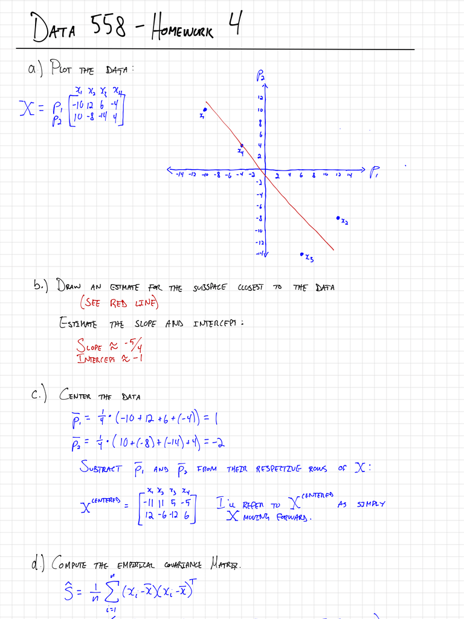

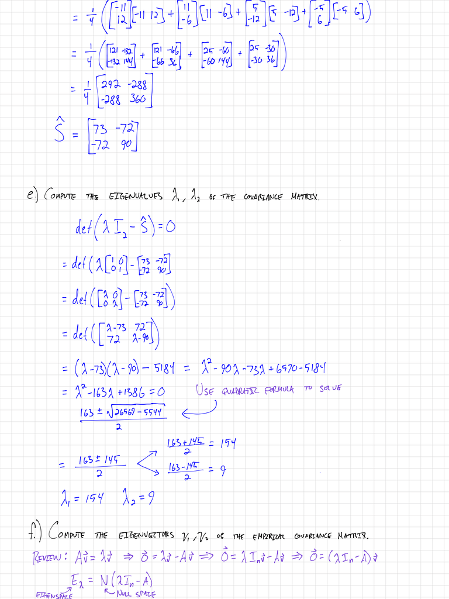

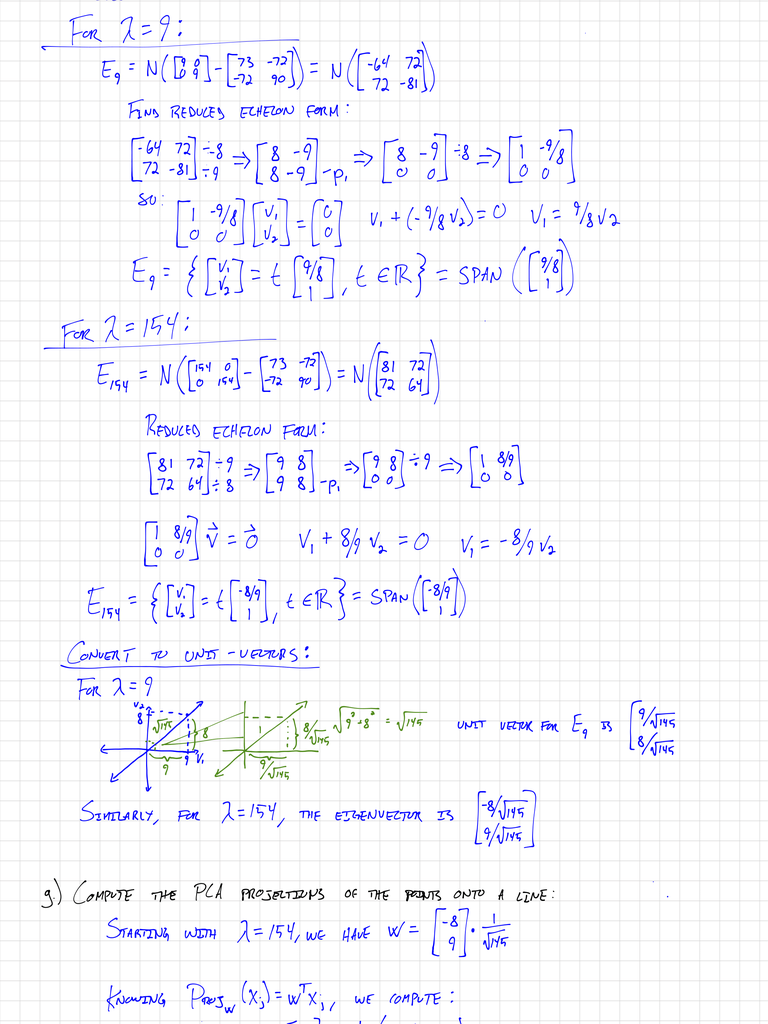

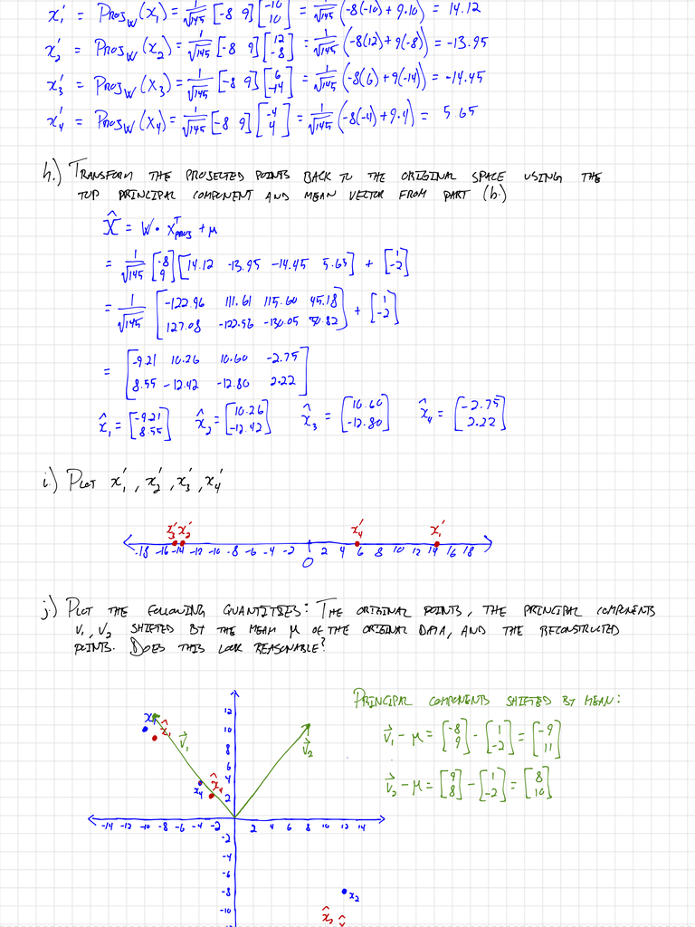

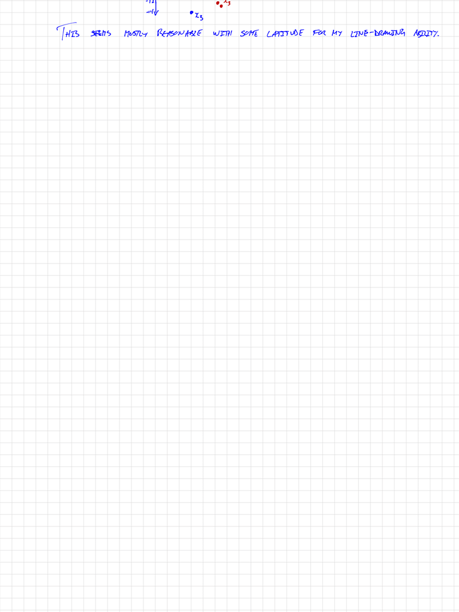

```python
from IPython.display import Image
from IPython.core.display import HTML

PATH = "/Users/Will/Documents/UW/DATA558/WEEK04/"
Image(filename = PATH + "data558_willWright_hw04_pca-handwritten-1.png", width=800)
Image(filename = PATH + "data558_willWright_hw04_pca-handwritten-2.png", width=800)
Image(filename = PATH + "data558_willWright_hw04_pca-handwritten-3.png", width=800)
Image(filename = PATH + "data558_willWright_hw04_pca-handwritten-4.png", width=800)
Image(filename = PATH + "data558_willWright_hw04_pca-handwritten-5.png", width=800)
```

Note: the final vectors should have been shifted by the means $(1,-2)$ and this is why it doesn't quite line up.

## Exercise 2

(a) Generate a simulated data set with 30 observations in each of three classes (i.e. 90 observations total), and 60 features. Hint: There are a number of functions in numpy that you can use to generate data. One example is the numpy.random.normal() function; numpy.random.uniform() is another option. Be sure to add a mean shift to the observations in each class so that there are three distinct classes.

```python
# Load Packages
import numpy as np
import matplotlib.pyplot as plt
import pandas as pd
```

```python
np.random.seed(0)
```

```python
class1 = pd.DataFrame(np.random.normal(loc = 10, scale = 1, size=(30, 60)))
class2 = pd.DataFrame(np.random.normal(loc = 0, scale = 1, size=(30, 60)))
class3 = pd.DataFrame(np.random.uniform(low = -15, high = -5, size=(30, 60)))
labels = np.repeat(['class1','class2','class3'],30)
X = pd.concat([class1,class2, class3])
X.index = labels
X.index.names = ['class']
```

(b) Write your own power iteration algorithm. Run it on the 90 observations to compute the first principal component. After performing the appropriate projection (see Lab #4), run it on the 90 observations now to compute the second principal component. Plot the first two principal component score vectors. Compare your results to the ones obtained with scikit-learn’s PCA algorithm. Use a different color to indicate the observations in each of the three classes. If the three classes appear separated in this plot, then you’re done. If not, then return to part (a) and modify the simulation so that there is greater separation between the three classes.

**Comment** I skipped to exercise 3 since I really wanted to submit something for the data competition this week. I'm struggling really hard though and I can't seem to get the right answers. The theory of PCA makes sense, but I'm still not getting the python and, shamefully, I can't get this power iteration to work.

```python
def power_iteration(A, max_iter = 1000):
    n,d = A.shape
    v = np.random.normal(size = (d,))
    v /= np.linalg.norm(v) # scale v down
    lamb = v.T @ (A @ v)
    for i in range(max_iter):
        # things I'm not getting
```

## Exercise 3 - Data Competition Project

(a) Pick two classes of your choice from the dataset

```python
from sklearn.model_selection import train_test_split
from sklearn import preprocessing
from sklearn.linear_model import LogisticRegressionCV
from sklearn.decomposition import PCA
import copy

# Load data
x_train = np.load('C:/Users/Will/Documents/data_competition1_files/train_features.npy')
y_train = np.load('C:/Users/Will/Documents/data_competition1_files/train_labels.npy')
x_val = np.load('C:/Users/Will/Documents/data_competition1_files/val_features.npy')
y_val = np.load('C:/Users/Will/Documents/data_competition1_files/val_labels.npy')
```

```python
# Subset of data (selecting group 5 and 9)
class1 = 5
class2 = 9
train_ids = np.array([np.where(y_train==class1),np.where(y_train==class2)]).reshape(-1)
x_train = x_train[train_ids]
y_train = y_train[train_ids]
val_ids = np.array([np.where(y_val==class1),np.where(y_val==class2)]).reshape(-1)
x_val = x_val[val_ids]
y_val = y_val[val_ids]
```

```python
# Standardize data and update labels to +/- 1
x_train = preprocessing.scale(x_train).T
x_val = preprocessing.scale(x_val).T
y_train = y_train.T
y_train[y_train==class1] = 1
y_train[y_train==class2] = -1
y_val = y_val.T
y_val[y_val==class1] = 1
y_val[y_val==class2] = -1
```

(b) Run PCA on this subset of the data using Scikit-Learn and project the data down to two dimensions

```python
# PCA
pca = PCA(svd_solver='full')
pca = pca.fit(x_train.T)
print("The first principle component:\n", pca.components_[0])
print("\nThe second principle component:\n", pca.components_[1])

# Project subset data down to two dimensions
x_train_2 = np.array([pca.components_[0],pca.components_[1]]).dot(x_train)
x_val_2 = np.array([pca.components_[0],pca.components_[1]]).dot(x_val)
```

```
The first principle component:
 [0.02859974 0.01307558 0.00177211 ... 0.02142714 0.00544708 0.00801531]

The second principle component:
 [ 0.00345246  0.03569749 -0.00138866 ...  0.00785782  0.0184915
 -0.01779129]
```

(c) You will be training an $l_2$-regularized logistic regression classifier. Find the value of the regularization paramater $\lambda$ using Scikit-Learn with 5-fold cross-validation.

```python
# Find optimal lambda by 5-fold cross-validation
n = x_train_2.shape[1]
clf = LogisticRegressionCV(cv=5, penalty='l2', fit_intercept=False, tol=10e-8, max_iter=1000)
fit = clf.fit(x_train_2.T, y_train)
lamb_opt = 1/(2*n*clf.C_[0])
print("The optimal value of lambda is", lamb_opt)
```

```
The optimal value of lambda is 0.08340502686000296
```

(d) Train a classifier using $l_2$-regularized logistic regression on the training set using your own fast gradient algorithm.

```python
def computegrad(X, y, beta, lam = 0.05):
    'Output grad(F) given X, y, beta, and lambda'
    ## calc the nxn p-matrix
    # start with the diagonal of non-zeros
    n, d = X.shape
    P_diag = [0 for x in range(n)] # P is nxn
    for i in range(0,n):
        yXTbeta = y[i]*(X[i,:].T).dot(beta) # 1x1 * dx1 * 1xd = 1x1
        P_diag[i] = 1-(np.exp(yXTbeta))/(1+np.exp(yXTbeta))
    P = np.diagflat(P_diag) # nxn
    emp_risk = (-1/n)*(X.T.dot(P).dot(y.reshape(n,1))) # (dxn * nxn) = dxn; dxn * nx1 = dx1
    penalty = 2*lam*beta.reshape(d,1) # dx1
    grad_F = emp_risk + penalty #dx1 + dx1 = dx1
    return grad_F
```

```python
def computeobj(X, y, beta, lam = 0.05):
    'Output F (objective is to minimize) for any given X, y, beta, lam'
    n = X.shape[0]
    sum_terms = [0 for i in range(n)] # initialize list
    for i in range(0, n):
        sum_terms[i] = np.log(1+np.exp(-y[i]*X[i,:].T.dot(beta)))
    avg_summation = sum(sum_terms)/n
    regularization = lam*np.sum(beta**2)
    F = avg_summation + regularization
    return F
```

```python
def backtracking(X, y, beta, eta, alpha = 0.5, gamma = 0.8):
    'Output new eta for a given X, y, beta, eta, alpha, and gamma'
    grad = computegrad(X,y,beta)
    complete = False
    while complete == False:
        if computeobj(X, y, beta - eta*grad) < computeobj(X, y, beta) - alpha*eta*np.linalg.norm(grad)**2:
            complete = True
        else:
            eta = eta * gamma
    return eta
```

```python
def compute_eta(X, lam = 0.05):
    'returns initial step-size based on equation provided in lecture notes'
    eigenValues, eigenVectors = np.linalg.eig((1/len(X)) * X.T.dot(X))
    L = max(eigenValues) + lam
    return 1/L
```

```python
def fastgradalgo(X, y, eta, target = 10e-4, lam = 0.05):
    # initialize lists of betas, Fs, and grad(F)s
    # identical to standard gradient descent except theta is added and used in the computegrad subroutine
    beta = np.zeros((X.shape[1],1))
    theta = np.zeros((X.shape[1],1))
    betas = [beta] #start with the first beta included
    Fs = [computeobj(X,y,beta,lam)] # start with the first F included
    grad = computegrad(X,y,theta,lam)
    t=0
    while (np.linalg.norm(grad) > target):
        eta = backtracking(X, y, beta, eta)
        beta_prior = copy.copy(beta)
        beta = theta - eta * computegrad(X, y, theta, lam)
        theta = beta + (t/(t+3))*(beta - beta_prior)
        betas.append(beta)
        F = computeobj(X, y, beta, lam)
        Fs.append(F)
        grad = computegrad(X, y, theta, lam)
        t += 1
    return np.array(betas) #, np.array(Fs)
```

```python
# borrowed this objective function and the obj_plot below since I can't get mine to work
def obj(X, Y, beta, lamb):
    n = X.shape[1]
    return 1/n*np.sum(np.log(1+np.exp(np.multiply(-Y.T,X.T.dot(beta))))) + lamb*np.linalg.norm(beta)**2
```

```python
def obj_plot(X1, Y1, X2, Y2, vals, lam, dim):
    n = vals.shape[0] # number of iterations
    obj1 = np.zeros(n)
    obj2 = np.zeros(n)
    for i in range(n):
        obj1[i] = obj(X1, Y1, vals[i],lam)
        obj2[i] = obj(X2, Y2, vals[i],lam)
    plt.figure()
    plt.plot(obj1, label='Training Set')
    plt.plot(obj2, label='Validation Set')
    plt.xlabel('Iteration')
    plt.ylabel('Objective Value')
    plt.title('Objective Value over Iterations\nDimension = %d' %dim, fontsize=13)
    plt.legend()
    plt.show()

    return
```

```python
# Train on the training set
vals_fg = fastgradalgo(x_train_2.T, y_train, compute_eta(x_train_2), lam=lamb_opt)
```

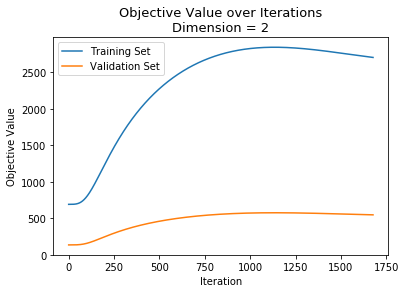

```python
# Plot objective values over iterations
obj_plot(x_train_2, y_train, x_val_2, y_val, vals_fg, lamb_opt, 2)
```

**Comments**: Welp, this ain't right.

(e) Repeat steps b-d, trying all power of two up to the number of features in the dataset.

**Can't proceed when I can't get the first working**

(f) Plot, with different colors, the misclassification error on the training set and on the test set vs. the dimension of the projection. Note that to obtain the performance on the test set you will need to submit to Kaggle, and you can only submit three times per day. If you only have enough tiem for three submissions, submit your predictions for dimensions 2, 16, 128.

**Can't submit to the data competition without something that works...**